# Préparation des données pour les bilans de GES

Author

Victor Nunzi

Published

June 2, 2023

Script *Quarto* visant préparer les données pour les bilans de GES.

Date du dernier *render* : 2023-06-30

```r
source("C:/Users/victo/OneDrive - ETS/MTR896/TRAVAIL/99_GitHub/MTR896/librairies/librairies.R")
source("C:/Users/victo/OneDrive - ETS/MTR896/TRAVAIL/99_GitHub/MTR896/fonctions/fonctions.R")
```

## 1 Répertoire

```r
setwd("C:/Users/victo/OneDrive - ETS/MTR896/TRAVAIL/99_GitHub/MTR896/bilanGES")
```

## 2 Données

On commence par charger les données :

```r
od18 <- read.csv("C:/Users/victo/OneDrive - ETS/MTR896/TRAVAIL/00_Donnees/od18niv2_plus.csv")

sf.munic_od18 <- st_read("C:/Users/victo/OneDrive - ETS/MTR896/TRAVAIL/00_Donnees/geom/municipalites/munic_od18_ges.shp", quiet = T)
sf.sm_od18    <- st_read("C:/Users/victo/OneDrive - ETS/MTR896/TRAVAIL/00_Donnees/geom/eod/shapefile-SM/SM_OD2018.shp",   quiet = T)
```

## 3 FE automobiles (municipalités)

On crée un *shapefile* avec les localisations des ménages :

```r
men <-
  od18 %>%
  group_by(m_numero) %>%
  summarise(
    m_domlon = unique(m_domlon),
    m_domlat = unique(m_domlat)
  )
```

On les convertit en *sf* :

```r
sf.men <- st_as_sf(men, coords = c("m_domlon", "m_domlat"),
                   crs = 4326)

sf.men <- st_transform(sf.men, crs = 32188)
```

On associe à chaque ménage un facteur d’émission automobile, basé sur la municipalité du domicile :

```r
sf.men <-
  st_join(sf.men, sf.munic_od18["MOY_CO2"],
          join = st_within)

st_write(sf.men, "C:/Users/victo/OneDrive - ETS/MTR896/TRAVAIL/00_Donnees/geom/municipalites/men_od18_ges.shp", quiet = T)
```

```
   Min. 1st Qu.  Median    Mean 3rd Qu.    Max.    NA's
  241.2   255.9   256.9   256.8   257.5   272.3      53
```

73368 associations réalisées sur un total de 73421 ménages (99.9 %).

Pour les 53 ménages sans facteur d’émissions automobiles, on prend la moyenne des autres valeurs (pondérées par les `m_fexp`) :

```r
sf.men$m_fexp <-
  od18$m_fexp[match(sf.men$m_numero, od18$m_numero)]

moy_FEauto_menages <-
  sum(sf.men$MOY_CO2*sf.men$m_fexp, na.rm = T)/
  sum(ifelse(is.na(sf.men$MOY_CO2), 0, sf.men$m_fexp))

print(moy_FEauto_menages)
```

```
[1] 256.7801
```

```r
sf.men$MOY_CO2 <-
  ifelse(is.na(sf.men$MOY_CO2),
         moy_FEauto_menages,
         sf.men$MOY_CO2)

summary(sf.men$MOY_CO2)
```

```
   Min. 1st Qu.  Median    Mean 3rd Qu.    Max.
  241.2   255.9   256.9   256.8   257.5   272.3
```

```r
od18$munic_FE_auto <-
  sf.men$MOY_CO2[match(od18$m_numero, sf.men$m_numero)]

od18$munic_FE_auto <- round(od18$munic_FE_auto)

summary(od18$munic_FE_auto)
```

```
   Min. 1st Qu.  Median    Mean 3rd Qu.    Max.
  241.0   255.0   257.0   256.7   257.0   272.0
```

## 4 Occupation moyenne des véhicules (par SM)

On calcule une occupation moyenne de véhicule par SM :

```r
od18 <- od18 %>%

  mutate(
    across(d_mode1:d_mode9, # on passe les modes en chaînes de caractères
           function(x){
             char <- as.character(x)
             char <- ifelse(str_length(char) == 1,      # le mode 1 devient "01", etc.
                            paste("0", char, sep = ""),
                            char)
             return(char)
             }
           )
  )


od18 <- od18 %>%
  unite("d_modeseq", d_mode1:d_mode9,
        remove = F, na.rm = T, sep = "-")

segm_auto.bySM <-
  od18 %>%

  pivot_longer(d_mode1:d_mode9,
               names_to  = "d_modenumber",
               values_to = "d_modevalue",
               values_drop_na = T) %>%

  filter(d_modevalue %in% c("01", "02")) %>%

  group_by(ipere) %>%

  mutate(
    segm_fexp = d_fexp/n()
  ) %>% ungroup() %>%

  group_by(m_domsm) %>%

  summarise(
    n_segm             = n(),
    n_segm_conduc      = sum(d_modevalue == "01"),
    n_segm_fexp        = sum(segm_fexp),
    n_segm_conduc_fexp = sum((d_modevalue == "01")*segm_fexp)
  ) %>% ungroup() %>%

  mutate(
    sm_occveh = round(n_segm_fexp/n_segm_conduc_fexp, 2)
  )
```

On ajoute les résultats aux SM :

```r
sf.sm_od18$sm_occveh <-
  segm_auto.bySM$sm_occveh[match(sf.sm_od18$Sm100,
                                 segm_auto.bySM$m_domsm)]

st_write(sf.sm_od18, "C:/Users/victo/OneDrive - ETS/MTR896/TRAVAIL/00_Donnees/geom/eod/shapefile-SM/SM_OD2018.shp",
         quiet = T, append = F)
```

## 5 FE automobiles (ménages)

Enfin, on calcule un facteur d’émission automobile moyen pour chaque ménage, tenant compte de l’occupation du véhicule :

```r
od18$sm_occveh <-
  sf.sm_od18$sm_occveh[match(od18$m_domsm,
                             sf.sm_od18$Sm100)]

summary(od18$sm_occveh)
```

```
   Min. 1st Qu.  Median    Mean 3rd Qu.    Max.
  1.120   1.190   1.230   1.227   1.260   1.350
```

```r
od18$m_FE_auto <- round(od18$munic_FE_auto/od18$sm_occveh)

summary(od18$m_FE_auto)
```

```
   Min. 1st Qu.  Median    Mean 3rd Qu.    Max.
  193.0   204.0   207.0   209.5   215.0   232.0
```

## 6 Invalidité des observations

On va maintenant identifier les déplacements “invalides”, c’est-à-dire les déplacements qu’on sait émetteurs mais dont il n’est pas possible d’estimer les émissions. Cela concerne :

- les déplacements émetteurs dont une coordonnée est manquante;
- les déplacements avec les modes `16` (interurbain) et `18` (indéterminé);
- les déplacements dont la distance réseau n’a pas pu être déterminée à l’aide de `r5r`.

```r
depl_emis       <- readRDS("C:/Users/victo/OneDrive - ETS/MTR896/TRAVAIL/00_Donnees/deplacements/depl_COMPLETE.Rds")
depl_r5rresults <- read.csv("C:/Users/victo/OneDrive - ETS/MTR896/TRAVAIL/00_Donnees/deplacements/depl_dist_r5rResults.csv")


od18$d_emiGES <-
  str_detect_vect(od18$d_modeseq,
                  c("01", "02", "11", "12",                   # automobile et moto
                    "03", "05", "06", "07", "09", "10", "15", # bus et TA
                    "08"))                                    # train
od18$d_emiGES <- as.integer(od18$d_emiGES)

od18$d_coordNA <-
  rowSums(
    is.na(
      od18 %>% dplyr::select(d_orilat,
                             d_orilon,
                             d_deslat,
                             d_deslon)
      )
  ) >= 1
od18$d_coordNA <- as.integer(od18$d_coordNA)



od18$d_isInvalid <-
  case_when(
    od18$p_mobil != 1                          ~ NA_integer_,
    od18$d_emiGES & od18$d_coordNA             ~ 1,
    (od18$ipere %in% depl_emis$ipere) &
      !(od18$ipere %in% depl_r5rresults$ipere) ~ 1,
    str_detect_vect(od18$d_modeseq,
                    c("16", "18"))             ~ 1,
    TRUE ~ 0
  )

depl       <- subset(od18, p_mobil == 1)
depl_valid <- subset(depl, !d_isInvalid)

pers <-
  depl %>%
  group_by(m_numero, p_rang) %>%
  summarise(p_isInvalid = as.integer(sum(d_isInvalid, na.rm = T) >= 1))

men <-
  depl %>%
  group_by(m_numero) %>%
  summarise(m_isInvalid = as.integer(sum(d_isInvalid, na.rm = T) >= 1))

depl_valid$p_isInvalid <-
  pers$p_isInvalid[match(paste(depl_valid$m_numero, depl_valid$p_rang),
                         paste(pers$m_numero,       pers$p_rang))]

depl_valid$m_isInvalid <-
  men$m_isInvalid[match(depl_valid$m_numero,
                        men$m_numero)]
```

- 1.1284^{4} déplacements invalides sur 357798 (3.2 %);
- 6351 personnes invalides sur 132855 (4.8 %);
- 5324 ménages invalides sur 64368 (8.3 %).

## 7 Méthode 1 – Distances réseau

On charge les facteurs d’émissions :

```r
FE_modes <- read.csv("data/FE_modes.csv")

FE_modes <- FE_modes %>%

  mutate(
    # on passe les modes en chaînes de caractères
    mode_num = as.character(mode_num),
    mode_num = ifelse(str_length(mode_num) == 1,      # le mode 1 devient "01", etc.
                            paste("0", mode_num, sep = ""),
                            mode_num)
  )
```

On commence par calculer un facteur d’émission en auto et en bus pour chaque déplacement

```r
## VOITURE :

segm_auto <-
  depl_valid %>%

  pivot_longer(d_mode1:d_mode9,
               names_to  = "s_modenumber",
               values_to = "s_modevalue",
               values_drop_na = T) %>%

  filter(s_modevalue %in% c("01", "02", "09", "11", "12", "15")) %>% # on sélectionne les modes dont les distances sont calculées sur le réseau viaire

  mutate(
    s_FE = FE_modes$mode_FE[match(s_modevalue, FE_modes$mode_num)]
  )

summary(segm_auto$s_FE)
```

```
   Min. 1st Qu.  Median    Mean 3rd Qu.    Max.    NA's
   35.0    35.0    35.0    59.2    35.0   264.0  244511
```

```r
table(subset(segm_auto, is.na(s_FE))$s_modevalue, useNA = "ifany")
```

```
    01     02     12
199051  45185    275
```

```r
segm_auto$s_FE <-
  ifelse(is.na(segm_auto$s_FE),
         od18$m_FE_auto[match(segm_auto$m_numero,
                              od18$m_numero)],
         segm_auto$s_FE)

summary(segm_auto$s_FE)
```

```
   Min. 1st Qu.  Median    Mean 3rd Qu.    Max.
   35.0   204.0   208.0   200.6   216.0   264.0
```

```r
depl_FE_auto_ntwk <-
  segm_auto %>%
  group_by(ipere) %>%
  summarise(d_FE_auto_ntwk = sum(s_FE)/n())

summary(depl_FE_auto_ntwk$d_FE_auto_ntwk)
```

```
   Min. 1st Qu.  Median    Mean 3rd Qu.    Max.
   35.0   204.0   208.0   200.7   216.0   264.0
```

```r
depl_valid$d_FE_auto_ntwk <-
  depl_FE_auto_ntwk$d_FE_auto_ntwk[match(depl_valid$ipere,
                                         depl_FE_auto_ntwk$ipere)]


## BUS :

segm_bus <-
  depl_valid %>%

  pivot_longer(d_mode1:d_mode9,
               names_to  = "s_modenumber",
               values_to = "s_modevalue",
               values_drop_na = T) %>%

  filter(s_modevalue %in% c("03", "05", "06", "07", "10")) %>% # on sélectionne les modes dont les distances sont calculées sur le réseau de bus

  mutate(
    s_FE = FE_modes$mode_FE[match(s_modevalue, FE_modes$mode_num)]
  )

summary(segm_bus$s_FE)
```

```
   Min. 1st Qu.  Median    Mean 3rd Qu.    Max.
   96.0    96.0    96.0   100.2    96.0   137.0
```

```r
depl_FE_bus <-
  segm_bus %>%
  group_by(ipere) %>%
  summarise(d_FE_bus = sum(s_FE)/n())

summary(depl_FE_bus$d_FE_bus)
```

```
   Min. 1st Qu.  Median    Mean 3rd Qu.    Max.
   96.0    96.0    96.0   100.1    96.0   137.0
```

```r
depl_valid$d_FE_bus <-
  depl_FE_bus$d_FE_bus[match(depl_valid$ipere,
                                   depl_FE_bus$ipere)]



## TRAIN
depl_valid$d_FE_train <- 119
```

```r
rm(depl_FE_auto_ntwk,
   depl_FE_bus,
   segm_auto,
   segm_bus)
```

Calcul des GES :

```r
## Ajout des distances :
depl_valid <- left_join(depl_valid,
                        depl_r5rresults %>% dplyr::select(ipere, d_dist_car_ntwk, d_dist_bus_ntwk, d_dist_rail_ntwk),
                        by = "ipere")

depl_valid <-
  depl_valid %>%
  mutate(
    across(d_dist_car_ntwk:d_dist_rail_ntwk,
           ~ ifelse(is.na(.), 0, .))
  )
```

```r
depl_valid$d_dist_emis_ntwk <-
  depl_valid$d_dist_car_ntwk +
  depl_valid$d_dist_bus_ntwk +
  depl_valid$d_dist_rail_ntwk

summary(depl_valid$d_dist_emis_ntwk)
```

```
   Min. 1st Qu.  Median    Mean 3rd Qu.    Max.
      0    1597    5240   10810   14989  154847
```

```r
depl_valid$d_gco2eq_m1 <-
  ifelse(depl_valid$d_dist_car_ntwk  > 0, depl_valid$d_dist_car_ntwk*depl_valid$d_FE_auto_ntwk/1000, 0) +
  ifelse(depl_valid$d_dist_bus_ntwk  > 0, depl_valid$d_dist_bus_ntwk*depl_valid$d_FE_bus/1000, 0) +
  ifelse(depl_valid$d_dist_rail_ntwk > 0, depl_valid$d_dist_rail_ntwk*depl_valid$d_FE_train/1000, 0)

print(
  sum(is.na(depl_valid$d_gco2eq_m1) & depl_valid$d_dist_emis_ntwk > 0)
)
```

```
[1] 0
```

```r
print(
  sum(depl_valid$d_gco2eq_m1 == 0 & depl_valid$ipere %in% depl_emis$ipere)
)
```

```
[1] 1164
```

```r
summary(depl_valid$d_gco2eq_m1)
```

```
   Min. 1st Qu.  Median    Mean 3rd Qu.    Max.
    0.0   243.6   903.5  2146.9  2859.7 34655.9
```

## 8 Méthode 2 et 3 – Distances à vol d’oiseau

On calcule les facteurs d’émissions de chaque déplacement :

```r
segm <-
  depl %>%
  filter(!d_isInvalid) %>%

  pivot_longer(d_mode1:d_mode9,
               names_to  = "s_modenumber",
               values_to = "s_modevalue",
               values_drop_na = T) %>%

  filter(s_modevalue != "14") %>% # on retire la marche
  filter(s_modevalue != "17") %>% # on retire les points de jonction

  mutate(
    s_FE = FE_modes$mode_FE[match(s_modevalue, FE_modes$mode_num)]
  )

summary(segm$s_FE)
```

```
   Min. 1st Qu.  Median    Mean 3rd Qu.    Max.    NA's
   0.00    0.00   35.00   57.43   96.00  264.00  244511
```

```r
table(subset(segm, is.na(s_FE))$s_modevalue, useNA = "ifany")
```

```
    01     02     12
199051  45185    275
```

Il reste les facteurs d’émission des voitures et des motos, on les ajoute :

```r
segm$s_FE <-
  ifelse(is.na(segm$s_FE),
         od18$m_FE_auto[match(segm$m_numero,
                              od18$m_numero)],
         segm$s_FE)

summary(segm$s_FE)
```

```
   Min. 1st Qu.  Median    Mean 3rd Qu.    Max.
    0.0    96.0   206.0   166.5   214.0   264.0
```

```r
depl_FE <-
  segm %>%
  group_by(ipere) %>%
  summarise(d_FE = sum(s_FE)/n())

summary(depl_FE$d_FE)
```

```
   Min. 1st Qu.  Median    Mean 3rd Qu.    Max.
    0.0   196.0   207.0   175.2   214.0   264.0
```

```r
depl_valid$d_FE <- depl_FE$d_FE[match(depl_valid$ipere, depl_FE$ipere)]

summary(depl_valid$d_FE)
```

```
   Min. 1st Qu.  Median    Mean 3rd Qu.    Max.    NA's
    0.0   196.0   207.0   175.2   214.0   264.0   35204
```

```r
table(subset(depl_valid, is.na(d_FE))$d_modeseq, useNA = "ifany")
```

```
   14
35204
```

Il reste seulement les déplacements à pieds, on leur donne un FE de 0 :

```r
depl_valid$d_FE <- ifelse(is.na(depl_valid$d_FE) & depl_valid$d_modeseq == "14",
                          0, depl_valid$d_FE)

summary(depl_valid$d_FE)
```

```
   Min. 1st Qu.  Median    Mean 3rd Qu.    Max.
    0.0    96.0   206.0   157.4   214.0   264.0
```

Enfin, on calcule les émissions à vol d’oiseau :

```r
depl_valid$d_dist_straight <-
  depl_emis$d_dist_straight[match(depl_valid$ipere,
                                  depl_emis$ipere)]

depl_valid$d_gco2eq_m2 <-
  ifelse(depl_valid$d_FE == 0, 0,
         depl_valid$d_FE*depl_valid$d_dist_straight/1000)

depl_valid$d_gco2eq_m3 <- depl_valid$d_gco2eq_m2*1.44

summary(depl_valid$d_gco2eq_m2)
```

```
   Min. 1st Qu.  Median    Mean 3rd Qu.    Max.
    0.0   162.4   591.3  1420.4  1861.6 24216.3
```

```r
summary(depl_valid$d_gco2eq_m3)
```

```
   Min. 1st Qu.  Median    Mean 3rd Qu.    Max.
    0.0   233.8   851.4  2045.4  2680.7 34871.5
```

## 9 Ecarts

```r
depl_valid$d_e_m2m1 <-
  case_when(
    depl_valid$d_gco2eq_m1 == 0 & depl_valid$d_gco2eq_m2 != 0 ~ NA_real_,
    depl_valid$d_gco2eq_m1 == 0 & depl_valid$d_gco2eq_m2 == 0 ~ 0,
    TRUE ~ (depl_valid$d_gco2eq_m2 - depl_valid$d_gco2eq_m1)/depl_valid$d_gco2eq_m1
    )

depl_valid$d_e_m3m1 <-
  case_when(
    depl_valid$d_gco2eq_m1 == 0 & depl_valid$d_gco2eq_m3 != 0 ~ NA_real_,
    depl_valid$d_gco2eq_m1 == 0 & depl_valid$d_gco2eq_m3 == 0 ~ 0,
    TRUE ~ (depl_valid$d_gco2eq_m3 - depl_valid$d_gco2eq_m1)/depl_valid$d_gco2eq_m1
    )

summary(depl_valid$d_e_m2m1)
```

```
   Min. 1st Qu.  Median    Mean 3rd Qu.    Max.    NA's
-1.0000 -0.4029 -0.3015 -0.2676 -0.1697 43.6250    1106
```

```r
summary(depl_valid$d_e_m3m1)
```

```
   Min. 1st Qu.  Median    Mean 3rd Qu.    Max.    NA's
-1.0000 -0.1402  0.0000 -0.0109  0.0655 63.2600    1106
```

```r
depl_valid$d_e_m2m1_abs <- abs(depl_valid$d_e_m2m1)
depl_valid$d_e_m3m1_abs <- abs(depl_valid$d_e_m3m1)

summary(depl_valid$d_e_m2m1_abs)
```

```
   Min. 1st Qu.  Median    Mean 3rd Qu.    Max.    NA's
 0.0000  0.1836  0.3067  0.3106  0.4092 43.6250    1106
```

```r
summary(depl_valid$d_e_m3m1_abs)
```

```
   Min. 1st Qu.  Median    Mean 3rd Qu.    Max.    NA's
 0.0000  0.0280  0.1041  0.1800  0.2155 63.2600    1106
```

Diagrammes en barres :

```r
barplot_em2m1 <-
  depl_valid %>%
  filter(!is.na(d_e_m2m1)) %>%
  mutate(
    intervalles = cut(d_e_m2m1, breaks = seq(-1, 1, .1), include.lowest = T, dig.lab = 1)
  ) %>%
  group_by(intervalles) %>%
  summarise(n = n())

barplot_em2m1$intervalles <-
  ifelse(is.na(barplot_em2m1$intervalles), "> 1.0", as.character(barplot_em2m1$intervalles))


barplot_em2m1$intervalles <- factor(barplot_em2m1$intervalles, levels = barplot_em2m1$intervalles)

# ggplot(data = barplot_em2m1, aes(x = intervalles, y = n)) +
#   geom_bar(stat="identity")



barplot_em3m1 <-
  depl_valid %>%
  filter(!is.na(d_e_m3m1)) %>%
  mutate(
    intervalles = cut(d_e_m3m1, breaks = seq(-1, 1, .1), include.lowest = T, dig.lab = 1)
  ) %>%
  group_by(intervalles) %>%
  summarise(n = n())

barplot_em3m1$intervalles <-
  ifelse(is.na(barplot_em3m1$intervalles), "> 1.0", as.character(barplot_em3m1$intervalles))


barplot_em3m1$intervalles <- factor(barplot_em3m1$intervalles, levels = barplot_em3m1$intervalles)
#
# ggplot(data = barplot_em2m1, aes(x = intervalles, y = n)) +
#   geom_bar(stat="identity")
```

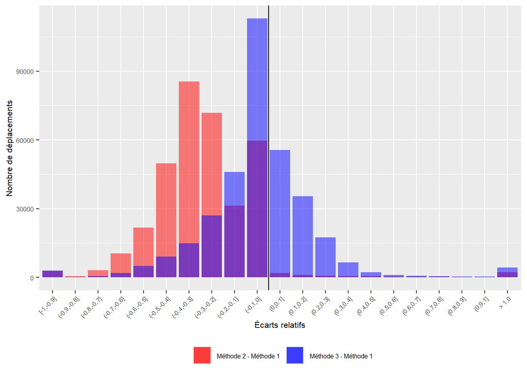

```r
combined <- barplot_em2m1 %>%
  rename(n_m2m1 = n) %>%
  mutate(n_m3m1 = barplot_em3m1$n[match(intervalles, barplot_em3m1$intervalles)])

ggplot(data = combined, aes(x = intervalles, y = n)) +
  geom_bar(aes(x = intervalles, y = n_m2m1, fill = "Méthode 2 - Méthode 1"), alpha = .5, stat="identity") +
  geom_bar(aes(x = intervalles, y = n_m3m1, fill = "Méthode 3 - Méthode 1"), alpha = .5, stat="identity") +
  geom_vline(xintercept = 10.5) +
  scale_fill_manual(values = c("Méthode 2 - Méthode 1" = "red", "Méthode 3 - Méthode 1" = "blue")) +
  xlab("Écarts relatifs") +
  ylab("Nombre de déplacements") +
  labs(fill = "") +
  theme(
    axis.title  = element_text(size=8),
    axis.text   = element_text(size=6),
    axis.text.x = element_text(angle = 45, hjust = 1),
    legend.text = element_text(size=6),
    legend.position = "bottom"
  )
```

```r
ggsave(
  file = "C:/Users/victo/OneDrive - ETS/MTR896/TRAVAIL/04_Rapport/LaTeX/Figures/hist_ecarts.png",
  width = 2000,
  height = 1500,
  units = "px"
)
```

## 10 Agrégation

### 10.1 Déplacements

Modes exclusifs :

```r
depl_valid <-
  depl_valid %>%
  mutate(
    d_auto_bin  = str_detect_vect(d_modeseq, c("01", "02", "11")),
    d_bus_bin   = str_detect_vect(d_modeseq, c("03", "05", "06", "07", "10")),
    d_metro_bin = str_detect_vect(d_modeseq, c("04")),
    d_train_bin = str_detect_vect(d_modeseq, c("08")),
    d_velo_bin  = str_detect_vect(d_modeseq, c("13")),
    d_autre_bin = str_detect_vect(d_modeseq, c("09", "12", "15")),

    across(d_auto_bin:d_autre_bin,
           ~ as.integer(.)),

    d_nbmodespasmarche =
      d_auto_bin + d_bus_bin + d_metro_bin +
      d_train_bin + d_velo_bin + d_autre_bin,

    d_modeexclu = case_when(
      d_nbmodespasmarche > 1  ~ "multimode",
      d_nbmodespasmarche == 0 ~ NA_character_,
      TRUE ~ case_when(
        d_auto_bin  == 1 ~ "auto",
        d_bus_bin   == 1 ~ "bus",
        d_metro_bin == 1 ~ "metro",
        d_train_bin == 1 ~ "train",
        d_velo_bin  == 1 ~ "velo",
        d_autre_bin == 1 ~ "autre"
      )
    )
  )

table(depl_valid$d_modeexclu, useNA = "ifany")
```

```
     auto     autre       bus     metro multimode     train      velo      <NA>
   238749     15732     16638     10933     23074      1008      5176     35204
```

```r
table(subset(depl_valid, is.na(d_modeexclu))$d_modeseq, useNA = "ifany")
```

```
   14
35204
```

```r
depl_valid$d_modeexclu <-
  ifelse(is.na(depl_valid$d_modeexclu),
         "marche",
         depl_valid$d_modeexclu)

table(depl_valid$d_modeexclu, useNA = "ifany")
```

```
     auto     autre       bus    marche     metro multimode     train      velo
   238749     15732     16638     35204     10933     23074      1008      5176
```

```r
summary_depl <-
  depl_valid %>%
  group_by(d_modeexclu) %>%
  summarise(
    n = n(),
    moy_gco2eq_m1 = weighted.mean(x = d_gco2eq_m1, y = d_fexp),
    moy_gco2eq_m2 = weighted.mean(x = d_gco2eq_m2, y = d_fexp),
    moy_gco2eq_m3 = weighted.mean(x = d_gco2eq_m3, y = d_fexp)
  ) %>%
  mutate(
    across(moy_gco2eq_m1:moy_gco2eq_m3,
           ~ round(.)),

    e_m2m1 =
      case_when(
        moy_gco2eq_m1 == 0 & moy_gco2eq_m2 != 0 ~ NA_real_,
        moy_gco2eq_m1 == 0 & moy_gco2eq_m2 == 0 ~ 0,
        TRUE ~ (moy_gco2eq_m2 - moy_gco2eq_m1)/moy_gco2eq_m1
        ),

    e_m3m1 =
      case_when(
        moy_gco2eq_m1 == 0 & moy_gco2eq_m3 != 0 ~ NA_real_,
        moy_gco2eq_m1 == 0 & moy_gco2eq_m3 == 0 ~ 0,
        TRUE ~ (moy_gco2eq_m3 - moy_gco2eq_m1)/moy_gco2eq_m1
        ),

    across(e_m2m1:e_m3m1,
           ~ round(., 3))
  )
```

| d_modeexclu | n | moy_gco2eq_m1 | moy_gco2eq_m2 | moy_gco2eq_m3 |
| --- | --- | --- | --- | --- |
| auto | 238749 | 2785 | 1878 (-32.6 %) | 2704 (-2.9 %) |
| autre | 15732 | 393 | 263 (-33.1 %) | 378 (-3.8 %) |
| bus | 16638 | 788 | 536 (-32 %) | 772 (-2 %) |
| marche | 35204 | 0 | 0 (0 %) | 0 (0 %) |
| metro | 10933 | 0 | 0 (0 %) | 0 (0 %) |
| multimode | 23074 | 2501 | 1249 (-50.1 %) | 1798 (-28.1 %) |
| train | 1008 | 2118 | 1925 (-9.1 %) | 2772 (30.9 %) |
| velo | 5176 | 0 | 0 (0 %) | 0 (0 %) |

### 10.2 Personnes

```r
summary_pers <-
  depl_valid %>%
  filter(!p_isInvalid) %>%

  group_by(m_numero, p_rang) %>%
  summarise(
    p_gco2eq_m1 = sum(d_gco2eq_m1),
    p_gco2eq_m2 = sum(d_gco2eq_m2),
    p_gco2eq_m3 = sum(d_gco2eq_m3),

    p_fexp  = unique(p_fexp),
    p_sexe  = unique(p_sexe),
    p_grage = unique(p_grage)
  ) %>% ungroup() %>%

  group_by(p_sexe, p_grage) %>%
  summarise(
    n = n(),
    moy_gco2eq_m1 = weighted.mean(x = p_gco2eq_m1, y = p_fexp),
    moy_gco2eq_m2 = weighted.mean(x = p_gco2eq_m2, y = p_fexp),
    moy_gco2eq_m3 = weighted.mean(x = p_gco2eq_m3, y = p_fexp)
  ) %>%
  mutate(
    across(moy_gco2eq_m1:moy_gco2eq_m3,
           ~ round(.)),

    e_m2m1 =
      case_when(
        moy_gco2eq_m1 == 0 & moy_gco2eq_m2 != 0 ~ NA_real_,
        moy_gco2eq_m1 == 0 & moy_gco2eq_m2 == 0 ~ 0,
        TRUE ~ (moy_gco2eq_m2 - moy_gco2eq_m1)/moy_gco2eq_m1
        ),

    e_m3m1 =
      case_when(
        moy_gco2eq_m1 == 0 & moy_gco2eq_m3 != 0 ~ NA_real_,
        moy_gco2eq_m1 == 0 & moy_gco2eq_m3 == 0 ~ 0,
        TRUE ~ (moy_gco2eq_m3 - moy_gco2eq_m1)/moy_gco2eq_m1
        ),

    across(e_m2m1:e_m3m1,
           ~ round(., 3))
  )

print(
  paste0("n min = ", min(summary_pers$n))
)
```

```
[1] "n min = 2957"
```

```r
print(
  paste0("n median = ", median(summary_pers$n))
)
```

```
[1] "n median = 5259.5"
```

```r
dt_pers <-
  summary_pers %>%
  mutate(
    moy_gco2eq_m2 = paste0(moy_gco2eq_m2, " (", e_m2m1*100, " %)"),
    moy_gco2eq_m3 = paste0(moy_gco2eq_m3, " (", e_m3m1*100, " %)")
  )

dt_pers <- cbind(
  dt_pers %>% pivot_wider(names_from = "p_sexe", values_from = "moy_gco2eq_m1", id_cols = "p_grage"),
  dt_pers %>% pivot_wider(names_from = "p_sexe", values_from = "moy_gco2eq_m2", id_cols = "p_grage"),
  dt_pers %>% pivot_wider(names_from = "p_sexe", values_from = "moy_gco2eq_m3", id_cols = "p_grage")
)

colnames(dt_pers) <-
  c("p_grage",
    "h_m1", "f_m1",
    "p_grage2",
    "h_m2", "f_m2",
    "p_grage3",
    "h_m3", "f_m3")

dt_pers$p_grage2 <- NULL
dt_pers$p_grage3 <- NULL
```

| p_grage | h_m1 | f_m1 | h_m2 | f_m2 | h_m3 | f_m3 |
| --- | --- | --- | --- | --- | --- | --- |
| 2 | 1366 | 1361 | 885 (-35.2 %) | 891 (-34.5 %) | 1274 (-6.7 %) | 1283 (-5.7 %) |
| 3 | 1726 | 1566 | 1133 (-34.4 %) | 1024 (-34.6 %) | 1632 (-5.4 %) | 1475 (-5.8 %) |
| 4 | 3617 | 3780 | 2329 (-35.6 %) | 2405 (-36.4 %) | 3354 (-7.3 %) | 3463 (-8.4 %) |
| 5 | 6668 | 6013 | 4275 (-35.9 %) | 3804 (-36.7 %) | 6156 (-7.7 %) | 5477 (-8.9 %) |
| 6 | 6991 | 6233 | 4680 (-33.1 %) | 4132 (-33.7 %) | 6740 (-3.6 %) | 5950 (-4.5 %) |
| 7 | 8280 | 7014 | 5508 (-33.5 %) | 4602 (-34.4 %) | 7931 (-4.2 %) | 6627 (-5.5 %) |
| 8 | 8563 | 7074 | 5665 (-33.8 %) | 4658 (-34.2 %) | 8158 (-4.7 %) | 6708 (-5.2 %) |
| 9 | 7387 | 6124 | 4923 (-33.4 %) | 4074 (-33.5 %) | 7089 (-4 %) | 5867 (-4.2 %) |
| 10 | 5859 | 4810 | 3938 (-32.8 %) | 3231 (-32.8 %) | 5671 (-3.2 %) | 4653 (-3.3 %) |
| 11 | 4532 | 3438 | 3068 (-32.3 %) | 2305 (-33 %) | 4418 (-2.5 %) | 3319 (-3.5 %) |

### 10.3 Ménages

```r
summary_men <-
  depl_valid %>%
  filter(!m_isInvalid) %>%

  group_by(m_numero) %>%
  summarise(
    m_gco2eq_m1 = sum(d_gco2eq_m1),
    m_gco2eq_m2 = sum(d_gco2eq_m2),
    m_gco2eq_m3 = sum(d_gco2eq_m3),

    m_fexp  = unique(m_fexp),
    m_domsm = unique(m_domsm)
  ) %>% ungroup() %>%

  group_by(m_domsm) %>%
  summarise(
    n = n(),
    moy_gco2eq_m1 = weighted.mean(x = m_gco2eq_m1, y = m_fexp),
    moy_gco2eq_m2 = weighted.mean(x = m_gco2eq_m2, y = m_fexp),
    moy_gco2eq_m3 = weighted.mean(x = m_gco2eq_m3, y = m_fexp)
  ) %>%
  mutate(
    across(moy_gco2eq_m1:moy_gco2eq_m3,
           ~ round(.)),

    e_m2m1 =
      case_when(
        moy_gco2eq_m1 == 0 & moy_gco2eq_m2 != 0 ~ NA_real_,
        moy_gco2eq_m1 == 0 & moy_gco2eq_m2 == 0 ~ 0,
        TRUE ~ (moy_gco2eq_m2 - moy_gco2eq_m1)/moy_gco2eq_m1
        ),

    e_m3m1 =
      case_when(
        moy_gco2eq_m1 == 0 & moy_gco2eq_m3 != 0 ~ NA_real_,
        moy_gco2eq_m1 == 0 & moy_gco2eq_m3 == 0 ~ 0,
        TRUE ~ (moy_gco2eq_m3 - moy_gco2eq_m1)/moy_gco2eq_m1
        ),

    across(e_m2m1:e_m3m1,
           ~ round(., 3))
  )

print(
  paste0("n min = ", min(summary_men$n))
)
```

```
[1] "n min = 58"
```

```r
print(
  paste0("n median = ", median(summary_men$n))
)
```

```
[1] "n median = 409"
```